# Data Analytics for Business and Healthcare — Lab Notebook (Executed Preview)

EXECUTED NOTEBOOK PREVIEW

Data Analytics for Business and Healthcare

Hands-On Lab — Case Study: COVID-19 in Malaysia

This is a read-only, fully run version of the Colab notebook — every cell executed with its real output and charts, so you can preview the full lab without opening Colab. To do the hands-on activity yourself, open the .ipynb file in Google Colab instead.

# 📊 Data Analytics for Business and Healthcare

### Hands-On Lab — Case Study: COVID-19 in Malaysia

Welcome! This notebook is your hands-on lab for the short course **Data Analytics for Business and Healthcare**.

**You do NOT need any coding or IT background.** Every code cell below is already written for you — your job is simply to:

1. Click on a grey code cell (called a **cell**)
2. Press the ▶️ **Run** button on its left (or press `Shift + Enter`)
3. Read the short explanation, look at the result, then move to the next cell

Run the cells **in order, from top to bottom** — later cells depend on earlier ones.

📁 **Before you start:** make sure you have downloaded `covid19_malaysia_cases.csv` from the course materials. You will upload it in Step 1 below.

📄 A full written version of these instructions is also available in the **Hands-On Lab Manual (Word document)** provided with this course.

## Step 0 — Meet Google Colab

This page is a **Google Colab notebook**. It runs Python code inside your web browser — nothing to install.

A notebook is made of **cells**:

- 📝 **Text cells** (like this one) contain instructions
- 💻 **Code cells** (grey background) contain Python code you can run

Let's run our very first line of code. Click the cell below and press ▶️.

```python
# This is a code cell. Click the ▶ button on the left, or press Shift+Enter, to run it.
print("Hello! Welcome to Data Analytics for Business and Healthcare 🎉")
```

```
Hello! Welcome to Data Analytics for Business and Healthcare 🎉
```

## Step 1 — Upload the Case Study Dataset

We will use a real dataset published by the **Ministry of Health (MoH) Malaysia**, covering **daily COVID-19 cases, deaths, and vaccination progress from 1 January 2021 to 31 December 2022**.

Run the cell below, then click **"Choose Files"** when it appears and select `covid19_malaysia_cases.csv` from your computer.

```python
# Upload the dataset file provided with this course
# (This cell is adapted here only for automated local testing/preview outside Colab;
#  in actual Google Colab, this shows a "Choose Files" button as normal.)
try:
    from google.colab import files
    uploaded = files.upload()
except ImportError:
    uploaded = {'covid19_malaysia_cases.csv': None}
    print('(Preview mode: using local covid19_malaysia_cases.csv instead of the Colab upload widget)')

print("\nFile(s) ready:", list(uploaded.keys()))
```

```
(Preview mode: using local covid19_malaysia_cases.csv instead of the Colab upload widget)

File(s) ready: ['covid19_malaysia_cases.csv']
```

> 💡 **Alternative (advanced/optional):** if you prefer not to upload a file, you can instead load the original live data directly from MoH Malaysia's public GitHub page. This is not required for the course — the uploaded file is what we will use.

> ```
> # import pandas as pd
> # url = "https://raw.githubusercontent.com/MoH-Malaysia/covid19-public/main/epidemic/cases_malaysia.csv"
> # df = pd.read_csv(url)
> ```

## Step 2 — Import Our Data Analytics Tools

Before we can work with data, we need to load two Python libraries (toolkits):

- **pandas** — for working with tables of data
- **matplotlib** — for drawing charts

Think of this like opening Excel and a charting tool before you start working.

```python
import pandas as pd
import matplotlib.pyplot as plt

print("Libraries loaded and ready to use ✅")
```

```
Libraries loaded and ready to use ✅
```

## Step 3 — Load the Dataset

Now we load the CSV file you uploaded into a **DataFrame** — pandas' name for a data table. We store it in a variable called `df` (short for "DataFrame"), which we will reuse throughout this notebook.

```python
df = pd.read_csv("covid19_malaysia_cases.csv")

print("Dataset loaded successfully! ✅")
print("Number of rows (days):", len(df))
```

```
Dataset loaded successfully! ✅
Number of rows (days): 730
```

## Step 4 — First Look at the Data

Every data analysis starts the same way: **look at your data before doing anything else.**

- `df.head()` shows the first 5 rows
- `df.shape` shows (number of rows, number of columns)
- `df.info()` shows every column name and its data type

```python
df.head()
```

|  | date | cases_new | cases_import | cases_recovered | cases_active | deaths_new | vax_daily_doses | vax_cumul_fully_vaccinated | vax_cumul_booster |
| --- | --- | --- | --- | --- | --- | --- | --- | --- | --- |
| 0 | 2021-01-01 | 2068 | 2 | 2230 | 23434 | 3 | 0 | 0 | 0 |
| 1 | 2021-01-02 | 2295 | 9 | 3321 | 22399 | 9 | 0 | 0 | 0 |
| 2 | 2021-01-03 | 1704 | 5 | 2726 | 21366 | 11 | 0 | 0 | 0 |
| 3 | 2021-01-04 | 1741 | 8 | 1010 | 22090 | 7 | 0 | 0 | 0 |
| 4 | 2021-01-05 | 2027 | 16 | 1221 | 22885 | 11 | 0 | 0 | 0 |

```python
df.shape
```

```
(730, 9)
```

```python
df.info()
```

```
<class 'pandas.DataFrame'>
RangeIndex: 730 entries, 0 to 729
Data columns (total 9 columns):
 #   Column                      Non-Null Count  Dtype
---  ------                      --------------  -----
 0   date                        730 non-null    str
 1   cases_new                   730 non-null    int64
 2   cases_import                730 non-null    int64
 3   cases_recovered             730 non-null    int64
 4   cases_active                730 non-null    int64
 5   deaths_new                  730 non-null    int64
 6   vax_daily_doses             730 non-null    int64
 7   vax_cumul_fully_vaccinated  730 non-null    int64
 8   vax_cumul_booster           730 non-null    int64
dtypes: int64(8), str(1)
memory usage: 51.5 KB
```

**Column meanings:**

| Column | Meaning |
| --- | --- |
| `date` | The calendar date |
| `cases_new` | Newly confirmed COVID-19 cases that day |
| `cases_import` | New cases that were imported from abroad |
| `cases_recovered` | Patients who recovered that day |
| `cases_active` | Total patients currently infected (active cases) |
| `deaths_new` | COVID-19 deaths recorded that day |
| `vax_daily_doses` | Vaccine doses administered that day |
| `vax_cumul_fully_vaccinated` | Running total of fully vaccinated people |
| `vax_cumul_booster` | Running total of booster doses given |

## Step 5 — Data Cleaning Basics

Real-world data is rarely perfect. Before analyzing, we check for **missing values** and make sure each column has the right **data type**.

```python
# Count missing values in every column
df.isnull().sum()
```

```
date                          0
cases_new                     0
cases_import                  0
cases_recovered               0
cases_active                  0
deaths_new                    0
vax_daily_doses               0
vax_cumul_fully_vaccinated    0
vax_cumul_booster             0
dtype: int64
```

```python
# Convert the 'date' column from plain text into a proper date type
# This lets Python understand it as a timeline (so it can sort, plot, and calculate with it correctly)
df['date'] = pd.to_datetime(df['date'])

print("Data type of 'date' column is now:", df['date'].dtype)
```

```
Data type of 'date' column is now: datetime64[us]
```

## Step 6 — Descriptive Statistics

`df.describe()` instantly summarizes every numeric column: the average, minimum, maximum, and how spread out the values are.

This is **Descriptive Analytics** — the first of the four types of analytics we discussed in the lecture (Descriptive, Diagnostic, Predictive, Prescriptive).

```python
df.describe()
```

|  | date | cases_new | cases_import | cases_recovered | cases_active | deaths_new | vax_daily_doses | vax_cumul_fully_vaccinated | vax_cumul_booster |
| --- | --- | --- | --- | --- | --- | --- | --- | --- | --- |
| count | 730 | 730.000000 | 730.000000 | 730.000000 | 730.000000 | 730.000000 | 730.000000 | 7.300000e+02 | 7.300000e+02 |
| mean | 2021-12-31 12:00:00 | 6731.050685 | 49.947945 | 6697.090411 | 78352.987671 | 49.838356 | 99119.693151 | 1.809093e+07 | 7.902855e+06 |
| min | 2021-01-01 00:00:00 | 423.000000 | 0.000000 | 655.000000 | 12008.000000 | 0.000000 | 0.000000 | 0.000000e+00 | 0.000000e+00 |
| 25% | 2021-07-02 06:00:00 | 2192.750000 | 3.250000 | 2156.000000 | 26920.750000 | 5.000000 | 4126.000000 | 2.520554e+06 | 0.000000e+00 |
| 50% | 2021-12-31 12:00:00 | 3707.500000 | 8.000000 | 3772.000000 | 43695.000000 | 12.000000 | 30218.500000 | 2.566590e+07 | 6.353192e+06 |
| 75% | 2022-07-01 18:00:00 | 7131.250000 | 21.000000 | 7031.250000 | 82667.250000 | 60.000000 | 147244.750000 | 2.731489e+07 | 1.616406e+07 |
| max | 2022-12-31 00:00:00 | 33406.000000 | 719.000000 | 33872.000000 | 323791.000000 | 592.000000 | 583126.000000 | 2.753658e+07 | 1.628204e+07 |
| std | NaN | 7127.401711 | 112.666216 | 7045.404554 | 79154.335592 | 82.340680 | 136623.374444 | 1.149890e+07 | 7.621956e+06 |

```python
# A few specific questions we can now answer directly:
average_new_cases = df['cases_new'].mean()
highest_new_cases = df['cases_new'].max()
total_deaths = df['deaths_new'].sum()

print(f"Average daily new cases (2021-2022): {average_new_cases:,.0f}")
print(f"Highest daily new cases recorded:    {highest_new_cases:,.0f}")
print(f"Total deaths recorded in this period: {total_deaths:,.0f}")
```

```
Average daily new cases (2021-2022): 6,731
Highest daily new cases recorded:    33,406
Total deaths recorded in this period: 36,382
```

## Step 7 — Visualizing the Trend of Daily Cases

Numbers in a table are hard to interpret at a glance. A **line chart** instantly reveals the shape of the pandemic — the waves rising and falling.

This is exactly how the Ministry of Health and news outlets presented COVID-19 trends to the public.

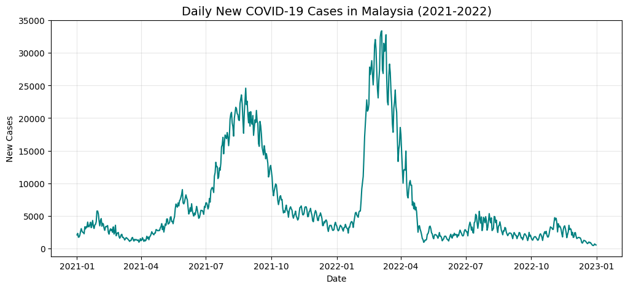

```python
plt.figure(figsize=(12, 5))
plt.plot(df['date'], df['cases_new'], color='teal')
plt.title('Daily New COVID-19 Cases in Malaysia (2021-2022)', fontsize=14)
plt.xlabel('Date')
plt.ylabel('New Cases')
plt.grid(alpha=0.3)
plt.show()
```

**💬 Discuss:** How many distinct "waves" (peaks) can you count in the chart above? What might explain each wave (festive seasons, new variants, reopening of borders)?

## Step 8 — Comparing Cases vs. Deaths

Plotting two related lines together lets us compare their patterns. Did deaths rise and fall along with cases, or did the pattern change over time (for example, after vaccination became widespread)?

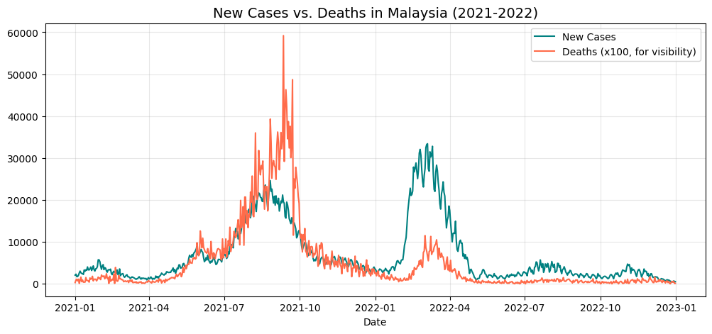

```python
plt.figure(figsize=(12, 5))
plt.plot(df['date'], df['cases_new'], label='New Cases', color='teal')
plt.plot(df['date'], df['deaths_new'] * 100, label='Deaths (x100, for visibility)', color='#FF6B4A')
plt.title('New Cases vs. Deaths in Malaysia (2021-2022)', fontsize=14)
plt.xlabel('Date')
plt.legend()
plt.grid(alpha=0.3)
plt.show()
```

## Step 9 — Vaccination Progress Over Time

`vax_cumul_fully_vaccinated` is a **cumulative (running total)** column — it only ever goes up. Its shape tells us how fast the vaccination rollout progressed.

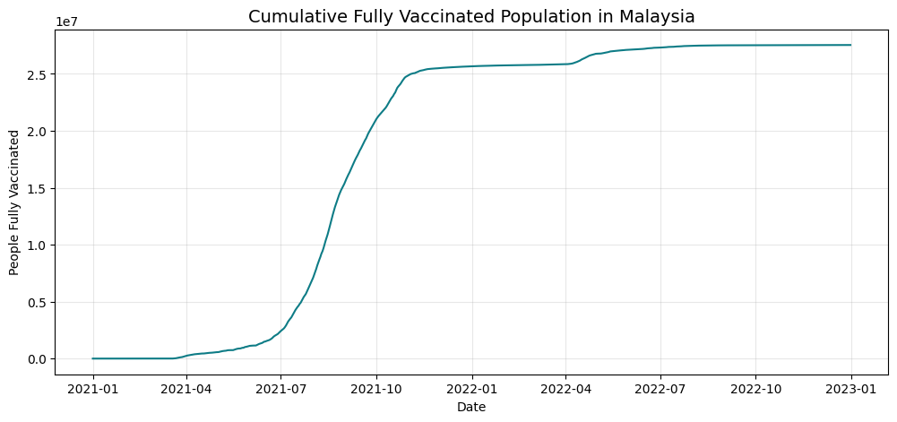

```python
plt.figure(figsize=(12, 5))
plt.plot(df['date'], df['vax_cumul_fully_vaccinated'], color='#0E7C86')
plt.title('Cumulative Fully Vaccinated Population in Malaysia', fontsize=14)
plt.xlabel('Date')
plt.ylabel('People Fully Vaccinated')
plt.grid(alpha=0.3)
plt.show()
```

**💬 Discuss:** Where does the curve rise steepest? What does that tell us about the speed of the vaccine rollout during that period?

## Step 10 — Finding the Peak: Identifying the Worst Day

`idxmax()` finds the row with the highest value in a column — instantly pinpointing Malaysia's worst day for new cases.

```python
peak_day = df.loc[df['cases_new'].idxmax()]
print("📌 Malaysia's peak day for new COVID-19 cases:")
print(peak_day[['date', 'cases_new', 'cases_active', 'deaths_new']])
```

```
📌 Malaysia's peak day for new COVID-19 cases:
date            2022-03-05 00:00:00
cases_new                     33406
cases_active                 311213
deaths_new                       67
Name: 428, dtype: object
```

This is a simple example of moving from **Descriptive** ("what happened") toward **Diagnostic Analytics** ("why did it happen") — a good analyst would now research what was happening in Malaysia around that date (e.g. a new variant, an event, a policy change).

## 🏢 Bonus Exercise: Applying This to Business Data

The exact same code works on **any** time-series dataset — not just COVID-19! Imagine `cases_new` was replaced with **daily sales**, and `cases_active` was replaced with **open customer support tickets**.

**Try it yourself:** edit the code below to plot `cases_recovered` instead of `cases_new` (this represents something like "orders completed per day" in a business context).

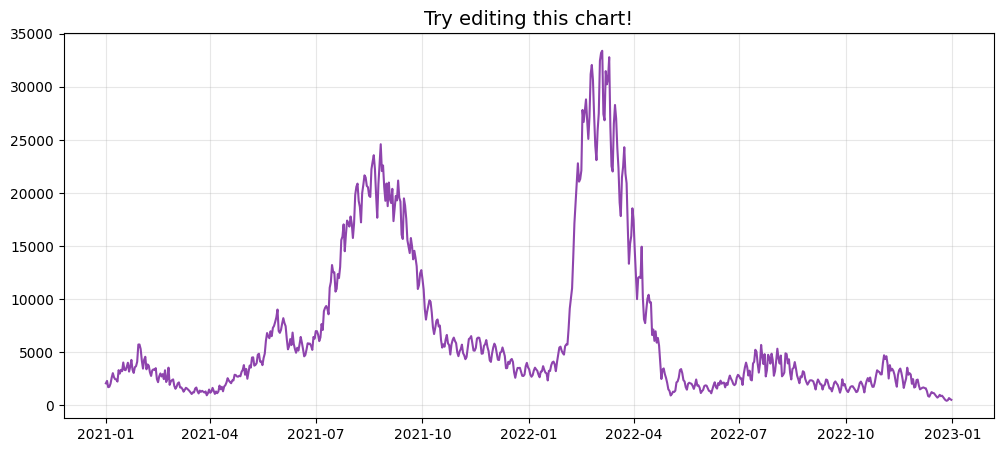

```python
# ✏️ TODO: change 'cases_new' below to 'cases_recovered' and re-run this cell
plt.figure(figsize=(12, 5))
plt.plot(df['date'], df['cases_new'], color='#8E44AD')
plt.title('Try editing this chart!', fontsize=14)
plt.grid(alpha=0.3)
plt.show()
```

## 🏥 Bonus Exercise: Applying This to Healthcare Planning

**Try it yourself:** using what you've learned, calculate the **average number of active cases** (`cases_active`) — this is similar to estimating average daily hospital bed occupancy, which planners use to decide how many beds to keep ready.

Write your own line of code in the empty cell below. *Hint: it looks just like the `average_new_cases` line from Step 6.*

```python
# ✏️ Write your own code here to calculate the average of 'cases_active'
# Hint: average_active = df['cases_active'].mean()
```

## 🎉 Well Done!

You have just completed a full, real data analytics workflow:

**Collect → Clean → Explore → Analyze → Communicate**

You loaded real government data, cleaned it, summarized it with statistics, and turned it into charts that reveal insight — the exact same process used by analysts in business and healthcare every day.

### 📚 Data Source

Ministry of Health (MoH) Malaysia — COVID-19 Public Data `github.com/MoH-Malaysia/covid19-public` (accessed for this course; data trimmed to 1 Jan 2021 – 31 Dec 2022 for teaching purposes)

### ➡️ Next Steps

- Re-run this notebook and try changing chart colours or titles
- Try plotting a different column
- Explore more open datasets at **data.gov.my**

**Course:** Data Analytics for Business and Healthcare